# Data 608 Assignment 1

Sung Lee

9/2/2021

** Original source for this assignment is from https://github.com/charleyferrari/CUNY_DATA_608/blob/master/module1/hw1.rmd

**Principles of Data Visualization and Introduction to ggplot2**

I have provided you with data about the 5,000 fastest growing companies in the US, as compiled by Inc. magazine. lets read this in:

```r
inc <- read.csv("https://raw.githubusercontent.com/charleyferrari/CUNY_DATA_608/master/module1/Data/inc5000_data.csv", header= TRUE)
```

And lets preview this data:

```r
head(inc)
```

|  | Rank | Name | Growth_Rate | Revenue | Industry | Employees | City | State |
| --- | --- | --- | --- | --- | --- | --- | --- | --- |
| 1 | 1 | Fuhu | 421.48 | 1.179e+08 | Consumer Products & Services | 104 | El Segundo | CA |
| 2 | 2 | FederalConference.com | 248.31 | 4.960e+07 | Government Services | 51 | Dumfries | VA |
| 3 | 3 | The HCI Group | 245.45 | 2.550e+07 | Health | 132 | Jacksonville | FL |
| 4 | 4 | Bridger | 233.08 | 1.900e+09 | Energy | 50 | Addison | TX |
| 5 | 5 | DataXu | 213.37 | 8.700e+07 | Advertising & Marketing | 220 | Boston | MA |
| 6 | 6 | MileStone Community Builders | 179.38 | 4.570e+07 | Real Estate | 63 | Austin | TX |

```r
summary(inc)
```

```
##       Rank          Name            Growth_Rate         Revenue
##  Min.   :   1   Length:5001        Min.   :  0.340   Min.   :2.000e+06
##  1st Qu.:1252   Class :character   1st Qu.:  0.770   1st Qu.:5.100e+06
##  Median :2502   Mode  :character   Median :  1.420   Median :1.090e+07
##  Mean   :2502                      Mean   :  4.612   Mean   :4.822e+07
##  3rd Qu.:3751                      3rd Qu.:  3.290   3rd Qu.:2.860e+07
##  Max.   :5000                      Max.   :421.480   Max.   :1.010e+10
##
##    Industry           Employees           City              State
##  Length:5001        Min.   :    1.0   Length:5001        Length:5001
##  Class :character   1st Qu.:   25.0   Class :character   Class :character
##  Mode  :character   Median :   53.0   Mode  :character   Mode  :character
##                     Mean   :  232.7
##                     3rd Qu.:  132.0
##                     Max.   :66803.0
##                     NA's   :12
```

Think a bit on what these summaries mean. Use the space below to add some more relevant non-visual exploratory information you think helps you understand this data:

```r
# Insert your code here, create more chunks as necessary
library(knitr)
library(xml2)
library(dplyr)
library(summarytools)
library(psych)

# For summarytools package
opts_chunk$set(results = 'asis',
                comment = NA,
                prompt  = FALSE,
                cache   = FALSE)

st_options(plain.ascii = FALSE,
            style        = "rmarkdown",
            footnote     = NA,
            subtitle.emphasis = FALSE)
```

```r
# Print out a frequency table of the data by Industry
freq(inc$Industry, order = "freq", plain.ascii = FALSE)
```

### Frequencies

**inc$Industry**  
**Type:** Character

|  | Freq | % Valid | % Valid Cum. | % Total | % Total Cum. |
| --- | --- | --- | --- | --- | --- |
| **IT Services** | 733 | 14.66 | 14.66 | 14.66 | 14.66 |
| **Business Products & Services** | 482 | 9.64 | 24.30 | 9.64 | 24.30 |
| **Advertising & Marketing** | 471 | 9.42 | 33.71 | 9.42 | 33.71 |
| **Health** | 355 | 7.10 | 40.81 | 7.10 | 40.81 |
| **Software** | 342 | 6.84 | 47.65 | 6.84 | 47.65 |
| **Financial Services** | 260 | 5.20 | 52.85 | 5.20 | 52.85 |
| **Manufacturing** | 256 | 5.12 | 57.97 | 5.12 | 57.97 |
| **Consumer Products & Services** | 203 | 4.06 | 62.03 | 4.06 | 62.03 |
| **Retail** | 203 | 4.06 | 66.09 | 4.06 | 66.09 |
| **Government Services** | 202 | 4.04 | 70.13 | 4.04 | 70.13 |
| **Human Resources** | 196 | 3.92 | 74.05 | 3.92 | 74.05 |
| **Construction** | 187 | 3.74 | 77.78 | 3.74 | 77.78 |
| **Logistics & Transportation** | 155 | 3.10 | 80.88 | 3.10 | 80.88 |
| **Food & Beverage** | 131 | 2.62 | 83.50 | 2.62 | 83.50 |
| **Telecommunications** | 129 | 2.58 | 86.08 | 2.58 | 86.08 |
| **Energy** | 109 | 2.18 | 88.26 | 2.18 | 88.26 |
| **Real Estate** | 96 | 1.92 | 90.18 | 1.92 | 90.18 |
| **Education** | 83 | 1.66 | 91.84 | 1.66 | 91.84 |
| **Engineering** | 74 | 1.48 | 93.32 | 1.48 | 93.32 |
| **Security** | 73 | 1.46 | 94.78 | 1.46 | 94.78 |
| **Travel & Hospitality** | 62 | 1.24 | 96.02 | 1.24 | 96.02 |
| **Media** | 54 | 1.08 | 97.10 | 1.08 | 97.10 |
| **Environmental Services** | 51 | 1.02 | 98.12 | 1.02 | 98.12 |
| **Insurance** | 50 | 1.00 | 99.12 | 1.00 | 99.12 |
| **Computer Hardware** | 44 | 0.88 | 100.00 | 0.88 | 100.00 |
| **<NA>** | 0 |  |  | 0.00 | 100.00 |
| **Total** | 5001 | 100.00 | 100.00 | 100.00 | 100.00 |

Here is a look at the data by using the `psych` library. This would be looking at variables with the mean, standard deviation, et al.

```r
# Growth Rate variable
describe(inc$Growth_Rate)
```

|  | vars | n | mean | sd | median | trimmed | mad | min | max | range | skew | kurtosis | se |
| --- | --- | --- | --- | --- | --- | --- | --- | --- | --- | --- | --- | --- | --- |
| X1 | 1 | 5001 | 4.611826 | 14.12369 | 1.42 | 2.136756 | 1.215732 | 0.34 | 421.48 | 421.14 | 12.54951 | 242.3366 | 0.1997192 |

```r
# Revenue variable
describe(inc$Revenue)
```

|  | vars | n | mean | sd | median | trimmed | mad | min | max | range | skew | kurtosis | se |
| --- | --- | --- | --- | --- | --- | --- | --- | --- | --- | --- | --- | --- | --- |
| X1 | 1 | 5001 | 48222535 | 240542281 | 10900000 | 17334966 | 10674720 | 2e+06 | 1.01e+10 | 1.0098e+10 | 22.17445 | 722.6563 | 3401441 |

```r
# Employeesvariable
describe(inc$Employees)
```

|  | vars | n | mean | sd | median | trimmed | mad | min | max | range | skew | kurtosis | se |
| --- | --- | --- | --- | --- | --- | --- | --- | --- | --- | --- | --- | --- | --- |
| X1 | 1 | 4989 | 232.718 | 1353.128 | 53 | 81.77511 | 53.3736 | 1 | 66803 | 66802 | 29.81042 | 1268.671 | 19.1572 |

Because of the large values for `Revenue`, it would be best to represent with log.

The following groups the data by City and State in descending order by Total Revenue in log form.

```r
inc %>%
    group_by(City, State) %>%
    summarise(totalRevenue = log(sum(Revenue))) %>%
    arrange(desc(totalRevenue))
```

| City | State | totalRevenue |
| --- | --- | --- |
| New York | NY | 23.07472 |
| Vernon Hills | IL | 23.03641 |
| Chicago | IL | 22.89084 |
| Houston | TX | 22.60320 |
| Beloit | WI | 22.27083 |
| Mt. Sterling | IL | 22.22734 |
| Cincinnati | OH | 22.21839 |
| Tarrytown | NY | 22.05948 |
| Huntersville | NC | 21.98082 |
| Washington | DC | 21.90769 |

[output cut: 1644 more lines]

## Question 1

Create a graph that shows the distribution of companies in the dataset by State (ie how many are in each state). There are a lot of States, so consider which axis you should use. This visualization is ultimately going to be consumed on a ‘portrait’ oriented screen (ie taller than wide), which should further guide your layout choices.

The solution below uses the `forcats` and `ggplot2` libraries. More information about `forcats` is here https://forcats.tidyverse.org/. I decided to go with a bar graph where the counts are organized by state in ascending order and the Tufte theme. I had a difficult time adjusting the labels and hope to remedy this in the future.

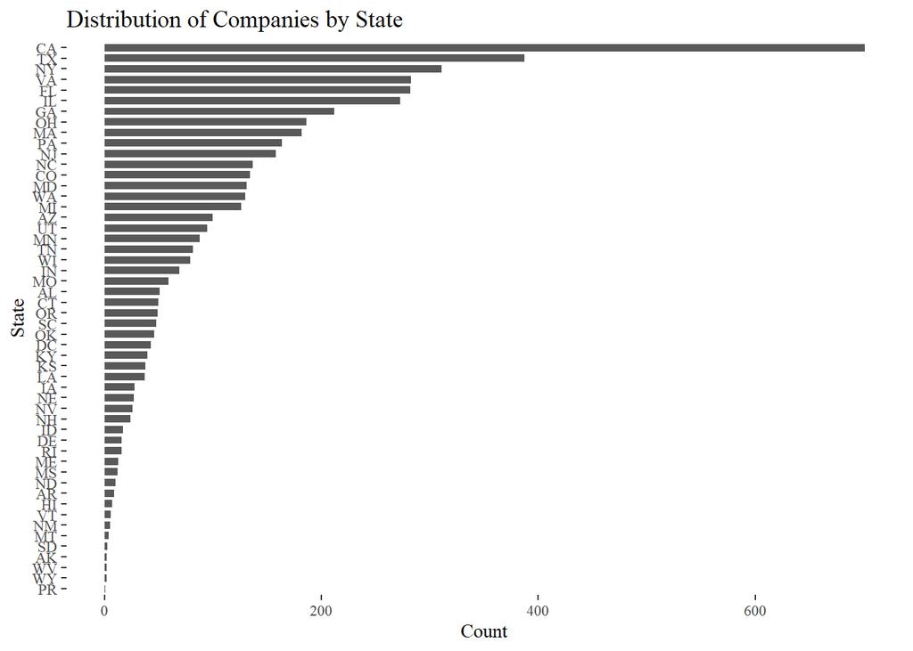

```r
# Answer Question 1 here

# For information about bar widths
# https://r-graphics.org/recipe-bar-graph-adjust-width
library(forcats)
library(ggplot2)
library(ggthemes)

# Used fct_rev to reverse the order because after coord_flip the least gets put on top
ggplot(inc, aes(x=fct_rev(fct_infreq(State)))) +
    geom_bar(stat="count", width = 0.7) +
    coord_flip() +
    xlab("State") +
    ylab("Count") +
    theme_tufte() +
    ggtitle("Distribution of Companies by State")
```

## Question 2

Lets dig in on the state with the 3rd most companies in the data set. Imagine you work for the state and are interested in how many people are employed by companies in different industries. Create a plot that shows the average and/or median employment by industry for companies in this state (only use cases with full data, use R’s `complete.cases()` function.) In addition to this, your graph should show how variable the ranges are, and you should deal with outliers.

```r
# Answer Question 2 here
library(scales)

# Get the NY data set
nyData <- inc[ which(inc$State == 'NY'), ]
# Remove incomplete records in the NY Dataset
nyData <- nyData[complete.cases(nyData), ]
# Display a sample
head(nyData)
```

|  | Rank | Name | Growth_Rate | Revenue | Industry | Employees | City | State |
| --- | --- | --- | --- | --- | --- | --- | --- | --- |
| 26 | 26 | BeenVerified | 84.43 | 13700000 | Consumer Products & Services | 17 | New York | NY |
| 30 | 30 | Sailthru | 73.22 | 8100000 | Advertising & Marketing | 79 | New York | NY |
| 37 | 37 | YellowHammer | 67.40 | 18000000 | Advertising & Marketing | 27 | New York | NY |
| 38 | 38 | Conductor | 67.02 | 7100000 | Advertising & Marketing | 89 | New York | NY |
| 48 | 48 | Cinium Financial Services | 53.65 | 5900000 | Financial Services | 32 | Rock Hill | NY |
| 70 | 70 | 33Across | 44.99 | 27900000 | Advertising & Marketing | 75 | New York | NY |

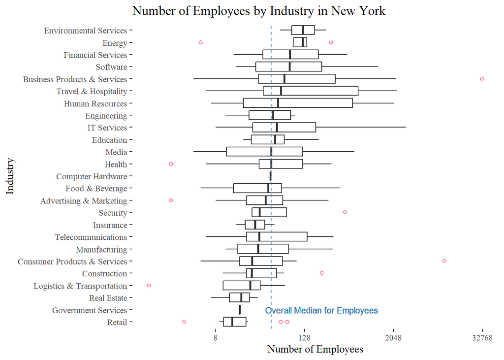

```r
# Obtain the max, min, and medians based on the Employees variable
upperNY <- max(nyData$Employees)
lowerNY <- min(nyData$Employees)
medianNY <- median(nyData$Employees)

# https://ggplot2.tidyverse.org/reference/geom_boxplot.html
ggplot(nyData, aes(reorder(Industry, Employees, FUN = median), Employees)) +
  geom_boxplot(outlier.colour = "#FF003C",
               outlier.shape = 1) +
  coord_flip() +
  geom_hline(yintercept = median(nyData$Employees),
             color="steelblue",
             linetype="dashed") +
  geom_text(aes(x=2,
            label="Overall Median for Employees", y = medianNY + 175),
            size = 3,
            colour="steelblue") +
  scale_y_continuous(trans = log2_trans(), limits = c(lowerNY, upperNY)) +
  xlab("Industry") +
  ylab("Number of Employees") +
  theme_tufte() +
  ggtitle("Number of Employees by Industry in New York")
```

From the previous problem, **NY** is the state with the 3rd most companies. The above graph uses log transformations to better capture the data within upper and lower bounds. The outliers were made to appear as empty red circles.

## Question 3

Now imagine you work for an investor and want to see which industries generate the most revenue per employee. Create a chart that makes this information clear. Once again, the distribution per industry should be shown.

```r
# Answer Question 3 here

# Store the complete cases
rpeData <- inc[complete.cases(inc), ]


# Create a new dataframe for plotting. Sums of Employees and Revenue become Employees_name and Revenue_name respectively
plotrpeData <- rpeData %>%
            group_by(Industry) %>%
            summarise_at(vars(Employees, Revenue), list(name = sum))

# Rename the columns for plotrpeData
names(plotrpeData)[names(plotrpeData)=="Revenue_name"] <- "Revenue"
names(plotrpeData)[names(plotrpeData)=="Employees_name"] <- "Employees"

plotrpeData$RPE <- plotrpeData$Revenue / plotrpeData$Employees

# Sample of the dataframe
head(plotrpeData)
```

| Industry | Employees | Revenue | RPE |
| --- | --- | --- | --- |
| Advertising & Marketing | 39731 | 7785000000 | 195942.7 |
| Business Products & Services | 117357 | 26345900000 | 224493.6 |
| Computer Hardware | 9714 | 11885700000 | 1223563.9 |
| Construction | 29099 | 13174300000 | 452740.6 |
| Consumer Products & Services | 45464 | 14956400000 | 328972.4 |
| Education | 7685 | 1139300000 | 148249.8 |

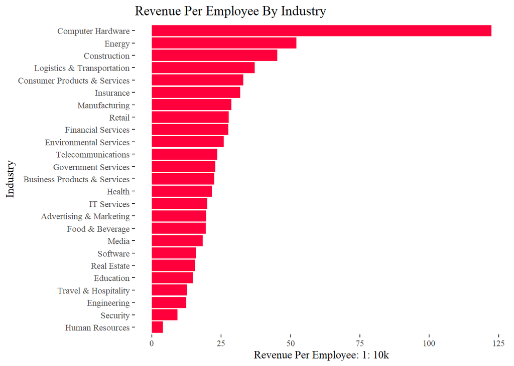

```r
# Create the plot
ggplot(plotrpeData, aes(x=reorder(Industry, RPE), y=RPE/10000)) +
    geom_bar(stat="identity", fill="#FF003C") +
    coord_flip() +
    xlab("Industry") +
    ylab("Revenue Per Employee: 1: 10k") +
    theme_tufte() +
    ggtitle("Revenue Per Employee By Industry")
```

It looks like `Computer Hardware`, `Energy`, and `Construction` are the top three industries generate the most revenue per employee.